# M06-Reflection Essay-Advanced Data Wrangling

Author

Ruben Garcia

Published

October 4, 2026

# 1 Introduction

**NoteAbout this report**

This report is what was reflection of the information in Module 6. It covers two topics: Revealjs presentations built with Quarto (Steps 1 and 2) and advanced data wrangling in R (Step 3).

# 2 Revealjs Presentations

## 2.1 Step 1: My Impression

> **Prompt:** In Step 1, I learned how to design stunning presentation slides with Quarto. What’s your impression of the Revealjs presentation? Describe its capabilities as you learned from the presentations. What are its strengths and weaknesses compared with PPT?

Initially this allowed me to think about how easy it is to turn a quarto document into a presentation. Exploring the many options provided by the software; displaying notes and formatting become so much easier. Formatting longer phrases and report style wording allows both presenter and audience understand the main purposes.

### 2.1.1 Capabilities

Revealjs slides are written in plain text inside a `.qmd` file, and Quarto turns them into an HTML slide deck. Based on the example presentations, the main capabilities include:

- **Literate programming in slides:** R code, tables, and charts are generated when the deck is rendered, so they are reproducible.
- **Layout tools:** columns, incremental lists, and speaker notes.
- **Navigation and effects:** slide transitions, overview mode, and vertical slides.
- **Themes:** built-in themes and custom CSS.
- **Sharing:** the deck is a web page, so it can be published as a link (for example, on GitHub Pages.

### 2.1.2 Revealjs vs. PowerPoint

**Strengths**

1. Charts and tables update automatically when the data or code changes.
2. Slides are plain text, so they work well with version control.
3. One link works on any device, with no software to install.
4. Consistent styling comes from themes rather than slide-by-slide formatting.

**Weaknesses**

1. There is a learning curve for the syntax.
2. Free-form drag-and-drop design is harder than in PowerPoint.
3. Collaboration is harder, because many people are used to editing PPT files together.
4. Offline presenting needs a saved HTML file or a PDF export.

## 2.2 Step 2: My Published Presentation

> **Prompt:** In Step 2, you were asked to create a Revealjs presentation. Provide a link to the presentation you published on the web. Add at least one reproducible chart or table in the presentation. Briefly describe what the presentation is about.

*What It Is About*

My presentation is about Group 3’s overall PO’s and my personal AO1.

### 2.2.2 Reproducible Chart

The chart in my presentation is produced by code, not pasted in as an image. Here is an example of that approach, using the built-in `mtcars` data:

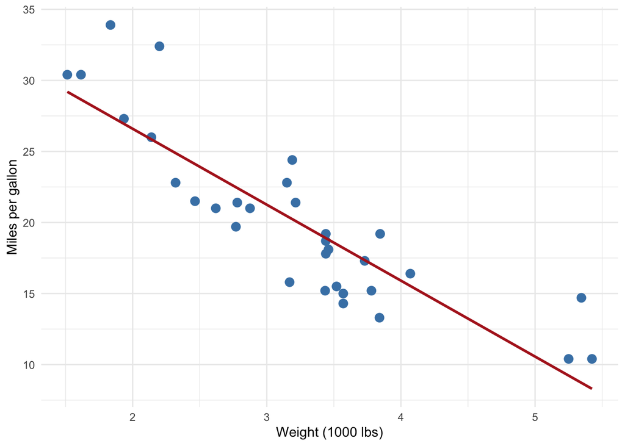

Figure 1: Fuel efficiency by car weight (example of a reproducible chart)

```r
ggplot(data = mtcars, mapping = aes(x = wt, y = mpg)) +
  geom_point(size = 3, color = "steelblue") +
  geom_smooth(method = "lm", se = FALSE, color = "firebrick") +
  labs(x = "Weight (1000 lbs)", y = "Miles per gallon") +
  theme_minimal()
```

Figure 1 shows the pattern. Because the chart is built from code, it updates itself whenever the data changes.

## 2.3 What I Learned

> **Prompt:** What did you learn from the experience of the Revealjs presentation?